# Exploring Online Car Listings Using SciKit Learn

201347125

14 April, 2020

This essay presents the results of a python based machine learning exercise in which car prices scraped from Ebay listings are explored. The dataset is freely available from [Kaggle](https://www.kaggle.com/orgesleka/used-cars-database), under the [CC0](https://creativecommons.org/publicdomain/zero/1.0/) licence. It should be noted that significant amount of pre-cleaning was performed on this data to present it in a usable state for this assessment. For readability this pre-cleaning is included as an Appendix.

# Exploring the Data

First the required libraries are loaded, including `pandas` for working with dataframes and `matplotlib` for plotting.

```python
import pandas as pd
import matplotlib.pyplot as plt

from pandas.api.types import CategoricalDtype  # convert var to categorical
from typing import List  # for type checking
```

The data is then loaded in as a `pandas` dataframe, the continuous and categorical variables identified.

```python
# read in pre-cleaned car data, set index to first col
df = pd.read_csv('~/data/car_ml/derived/cars_cleaned.csv', index_col=0)
# list all continuous variables
cont_vars = [
    'price',
    'age',
    'powerPS',
    'kilometer'
]
# list all categorical variables
cat_vars = [
    'vehicleType',
    'gearbox',
    'fuelType',
    'area',
    'brand'
]
```

To explore the continuous variables, a histogram may be plotted for each.

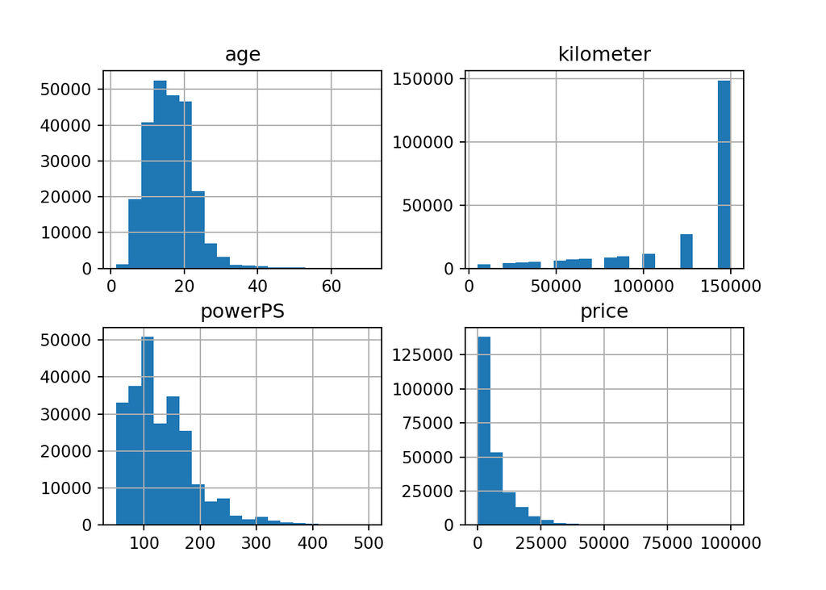

```python
df[cont_vars].hist(bins=20)
```

This figure indicates there there appears to be a significant positive skew with the `price` variable, this positive skew is also apparent with `powerPS`. The skew may be measured with the pandas `.skew()` method; `powerPS` has a skew of 1.5, while `price` has a skew of 3.08. This skew will be explored later in the supervised learning section. Additionally `kilometer` shows gaps between certain bins, an unusual property for a continuous variable.

Below is a table of the categorical variables using the pandas `describe()` method;

```python
cat_desc = pd.DataFrame(df[cat_vars].describe().T)
```

```r
# r code for neat html tables
py$cat_desc %>%
    kable() %>%
    kable_styling()
```

|  | count | unique | top | freq |
| --- | --- | --- | --- | --- |
| vehicleType | 243862 | 8 | limousine | 72434 |
| gearbox | 243862 | 2 | manual | 185738 |
| fuelType | 243862 | 7 | petrol | 155949 |
| area | 243768 | 16 | Nordrhein-Westfalen | 56687 |
| brand | 243862 | 40 | volkswagen | 50444 |

Both `area`, `brand`, `vehicleType` and `fuelType` contain a large number of categories, which contain spare numbers of values. For this reason a method was devised to remove categories containing fewer observations. The `top_cats` function provides the options for an input dataframe, the variable to reduce and the number of categories to keep, outputting the dataframe with rows excluded that were part of a removed category. `brand` is dropped due to the large sparsity of categories compared with other variables.

```python
df = df.drop(columns=['brand'])  # too many sparse categories
cat_vars.remove('brand')


def top_cats(df: pd.DataFrame, var: str, num: int):
    """Keep a number of top categories from a categorical variable in a df.

    Retain the top 'num' categories from a column 'var' in
    a dataframe 'df', uses the total row count of each category.

    Args:
        df (pd.DataFrame): pandas dataframe
        var (str): valid row name in df
        num (int): cats to keep with size < total number of unique values in var
    """
    df = df[df[var].isin(
        df[var]
        .value_counts()
        .head(num)
        .index
        .tolist())]
    return df


# keep only top two fuel groups, petrol and diesel
df = top_cats(df=df, var='fuelType', num=2)
# reduce the number of categories to 5 for others, removing the least used
for var in cat_vars:
    df = top_cats(df=df, var=var, num=5)
```

The `fuelType` variable was further reduced to only two categories, `petrol` and `diesel` as others contained very few observations. As noted previously, the `kilometer` variable doesn’t appear to behave as a normal continuous variable. The unique values for `kilometer` are explored;

```python
# more like a categorical variable, and skewed to higher values
df['kilometer'].value_counts()
```

```
150000    93633
125000    17142
100000     7163
90000      5937
80000      5324
70000      4857
60000      4221
50000      3807
40000      3302
30000      2993
20000      2752
5000       1046
10000       895
Name: kilometer, dtype: int64
```

Unlike a normal continuous variable, there are very few unique values, and many repeated values. For this reason it is perhaps more accurate to consider `kilometer` as an ordinal variable. First to reduce the number of categories, any value below 100,000 was contained within a new group (<100,000) and the variable converted into categoric.

```python
# combine lower kilometer values into one
df.loc[:, 'kilometer'][df['kilometer'] < 100000] = "<100000"
# change kilometer variable to categorical (doesn't need to be ordered)
df.loc[:, 'kilometer'] = df.loc[:, 'kilometer']\
    .astype(CategoricalDtype())

# fix the cont and cat vars lists
cont_vars.remove('kilometer')
cat_vars.append('kilometer')
```

Following this cleaning, this dataset now contains 153072.

# Unsupervised Learning

With the data cleaned appropriately, this section will explore a K Means clustering technique, and present methods for evaluating the number of $k$ clusters to choose, and how principal component analysis may improve clustering. First the appropriate libraries are loaded, `numpy` provides some simple mathematic expressions, `seaborn` is used for some more specific plotting and from the `sklearn` library, some preprocessing tools, the K Means and PCA functions, and two validation scores.

```python
import numpy as np
import seaborn as sns

from sklearn.preprocessing import scale, MinMaxScaler
from sklearn.cluster import KMeans
from sklearn.decomposition import PCA
from sklearn.metrics import silhouette_score, calinski_harabasz_score
```

```python
# create a standardised dataframe using continuous vars
df_std = scale(df[cont_vars])
df_std = pd.DataFrame(df_std, index=df.index, columns=cont_vars)

# create a range scaled dataframe using continuous vars
range_scaler = MinMaxScaler()
df_scaled = range_scaler.fit_transform(df[cont_vars])
df_scaled = pd.DataFrame(df_scaled, index=df.index, columns=cont_vars)
```

To determine the optimal number of K means clusters to select, the Calinski Harabasz Score for each dataframe, and a varying number of clusters are plotted as a line graph. The `plot_elbow`[^1] function takes the input dataframe, a min and max number of clusters, in this case 2 and 11, and outputs a series containing the CH score for each number of clusters in that dataframe.

```python
df_norms = [df, df_std, df_scaled]  # list of raw df and normalised


def plot_elbow(df: pd.DataFrame, mn: int, mx: int):
    """Plot elbow method for selecting optimal k in k means.

    Uses calinksi harabasz score to determine optimal number
    of clusters in k means analysis.

    Args:
        df (pd.DataFrame): pandas df with continuous variables
        mn (int): min number of clusters to attempt
        mx (int): max number of cluster to attempt
    """
    chss = {}
    # loop over min and max number of clusters
    for n in range(mn, mx):
        # init K means estimator, random state to keep same results
        estimator = KMeans(n_clusters=n, random_state=3425)
        estimator.fit(df[cont_vars])
        chs = calinski_harabasz_score(df[cont_vars],
                                      estimator.labels_)
        chss[n] = chs
    chss = pd.Series(chss)
    return chss

# list comprehension, output a list of series from plot_elbow() for each in df_norms
plts = [plot_elbow(df, mn=2, mx=11) for df in df_norms]
```

Each series was then plotted;

```python
def annotate_axes(f, title: str, x_lab: bool, y_lab: bool):
    """Easily annotate multiple axes

    Allows for removing axes labels and adding individual titles
    to multiple axes on the same figure at once.

    Args:
        f (Figure): matplotlib figure type
        title (str): title per axes
        x_lab (bool): show or hide x labs
        y_lab (bool): show or hide y labs
    """
    for i, ax in enumerate(f.axes):
        ax.tick_params(labelbottom=x_lab, labelleft=y_lab)
        ax.set_title(title[i])

f, ax = plt.subplots(1, 3)
[plts[i].plot.line(ax=ax[i]) for i, _ in enumerate(plts)]
```

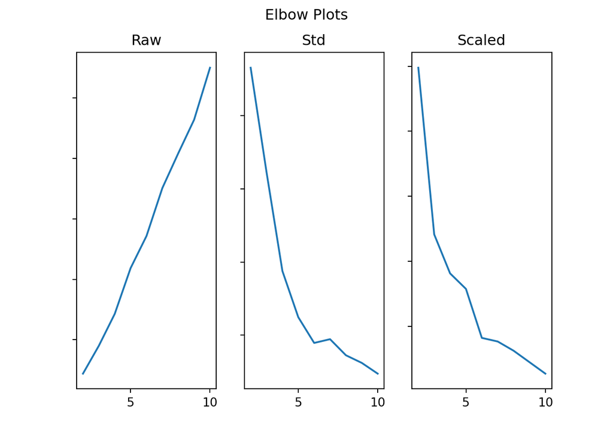

```python
annotate_axes(f, title=['Raw', 'Std', 'Scaled'], x_lab=True, y_lab=False)
f.suptitle('Elbow Plots')
plt.show()
```

This figure indicates that an optimal number of clusters is likely to be around 5, as the score at this number stops decreasing for both the standardised and scaled dataframe. Additionally, the lack of clear clusters for the non-transformed dataframe appear to indicate that due to the large variation in scales between variables, it is important to standardise them in order to reveal a pattern.

## Evaluation of K Means Clusters

With a suitable number of clusters chosen, the fit of this K Means clustering could now be assessed. First a function is defined to extract the $k$ labels from clustering performed on the three dataframes.

```python
# initial number of clusters
def k5_fits(df: pd.DataFrame):
    """Give KMeans labels for estimator

    Retrieve kmeans 5 cluster estimator labels and
    output a series.

    Args:
        df (pd.DataFrame): pandas df with vars for kmeans
    """
    global estimator  # allow this to be used outside this function
    estimator = KMeans(n_clusters=5, random_state=3425)
    estimator.fit(df[cont_vars])
    k5_fits = pd.Series(estimator.labels_, index=df.index)
    return k5_fits


# fit raw/std/scaled model
k5_fits = [k5_fits(df) for df in df_norms]
```

Following this, PCA may be performed on both the standardised and scaled dataframes, to obtain two derived components, the K Means labels for these additional dataframes are then retrieved.

```python
def k5_pca(df: pd.DataFrame):
    """Transform vars to components and output kmeans

    Use PCA to convert a number of vars to 2 components,
    uses components to run a kmeans and output series

    Args:
        df (pd.DataFrame): pandas df with vars for kmeans
    """
    global pca_estimator
    pca_estimator = PCA(n_components=2)
    components = pca_estimator.fit_transform(df[cont_vars])
    components = pd.DataFrame(components,
                              index=df.index,
                              columns=['C-1', 'C-2'])
    estimator.fit(components)
    k5_pca = pd.Series(estimator.labels_, index=components.index)
    return k5_pca


df_pca = [df_std, df_scaled]
# fit pca_std/pca_scaled
k5_pca = [k5_pca(df) for df in df_pca]

k5_fits.extend(k5_pca)
```

These five series containing K Means labels are then plotted as scatter plots and compared.

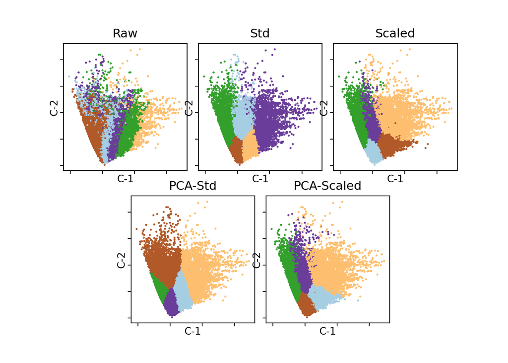

```python
def plt_components(labs: pd.Series, ax):
    """Represent KMeans clusters by 2d components

    Takes the components from a 2d PCA and plots clusters
    using these xy values on a scatter plot.

    Args:
        labs (pd.Series): k means labels
        ax (AxesSubplot): specific type of subplot
    """
    # choose std df components for visualisations
    components = pca_estimator.fit_transform(df_std[cont_vars])
    components = pd.DataFrame(components,
                              index=df.index,
                              columns=['C-1', 'C-2'])
    components.assign(labels=labs)\
        .plot.scatter('C-1',
                      'C-2',
                      c='labels',
                      s=1,
                      cmap='Paired',
                      colorbar=False,
                      ax=ax)


f = plt.figure()
ax1 = plt.subplot2grid(shape=(2, 6), loc=(0, 0), colspan=2)
ax2 = plt.subplot2grid((2, 6), (0, 2), colspan=2)
ax3 = plt.subplot2grid((2, 6), (0, 4), colspan=2)
ax4 = plt.subplot2grid((2, 6), (1, 1), colspan=2)
ax5 = plt.subplot2grid((2, 6), (1, 3), colspan=2)
axs = [ax1, ax2, ax3, ax4, ax5]

# for each axes plot one of the k means labels
for i, labs in enumerate(k5_fits):
    plt_components(labs, axs[i])
annotate_axes(f, title=['Raw', 'Std', 'Scaled', 'PCA-Std', 'PCA-Scaled'],
              x_lab=False, y_lab=False)
plt.show()
```

From these plots it appears qualitatively that the PCA - Standardised dataframe may produce the most appropriate K Means clusters. To quantitatively assess the K Means clusters, both the Calinski Harabasz, and Silhouette Scores may be compared between each. For both metrics, the higher the score the better.

```python
# use list comprehension to output a list of scores for each k means labels
chs = [calinski_harabasz_score(df[cont_vars], k5) for k5 in k5_fits]
ch_tab = pd.Series(
     {
         'Raw': chs[0],
         'Standardised': chs[1],
         'Scaled': chs[2],
         'PCA Standardised': chs[3],
         'PCA Scaled': chs[4]
     })
```

```python
def sil_scores(k5_fits: pd.Series):
    """Calculate silhouette scores for k means clusters.

    Take cluster labels as a series, a sample of the total data
    and calculates the fit.

    Args:
        k5_fits (pd.Series): K Means labels
    """
    sil_scores = silhouette_score(
        df[cont_vars],
        k5_fits,
        metric='euclidean',
        sample_size=10000
    )
    return sil_scores


sil_score = [sil_scores(fit) for fit in k5_fits]

sil_tab = pd.Series(
     {
         'Raw': sil_score[0],
         'Standardised': sil_score[1],
         'Scaled': sil_score[2],
         'PCA Standardised': sil_score[3],
         'PCA Scaled': sil_score[4]
     })

# convert both scores to cols in a df
scores_tab = pd.DataFrame()
scores_tab['Calinski Scores'] = ch_tab
scores_tab['Silhouette Scores'] = sil_tab
```

```r
py$scores_tab %>%
    kable() %>%
    kable_styling()
```

|  | Calinski Scores | Silhouette Scores |
| --- | --- | --- |
| Raw | 418513.13 | 0.6162205 |
| Standardised | 108888.15 | 0.1751258 |
| Scaled | 52418.04 | 0.0738040 |
| PCA Standardised | 87811.06 | 0.1714492 |
| PCA Scaled | 44783.80 | 0.0757759 |

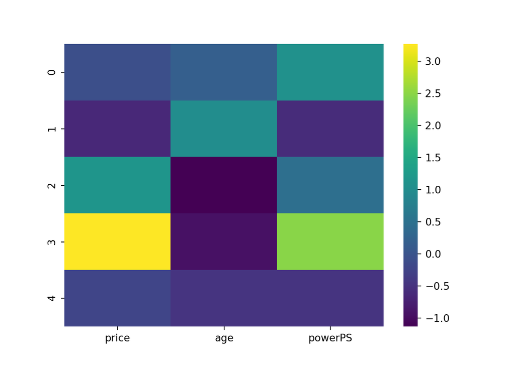

```python
g = df_std[cont_vars]\
    .groupby(k5_fits[1])
sns.heatmap(g.mean(), cmap='viridis')
plt.show()
```

# Supervised Learning

Following the unsupervised K Means clustering, this section will explore supervised techniques from the `sklearn` python library. The first being a linear regression, followed by a random forest regression. These two techniques will be compared along with the suitability of models chosen.

Both the linear regression and random forest models will attempt to determine an association with certain predictive variables in the dataset and the price of a vehicle.

```python
import time  # benchmarking

from sklearn.linear_model import LinearRegression
from sklearn.ensemble import RandomForestRegressor
from sklearn.metrics import r2_score
from sklearn.metrics import mean_squared_error as mse
from sklearn.model_selection import train_test_split, cross_val_score, GridSearchCV
```

## Linear Regression

This section outlines a linear regression using variables in the dataset to determine the association with the outcome variable `price`. In order to utilise the categorical variables in this dataset, they are first converted into dummy variables using the pandas function `get_dummies`. Additionally, as noted above, the `price` outcome variable shows significant skew. Linear Regression inherently assumes a linear relationship between variables, and as such it is frequently accepted that given a positively skewed outcome variable, the log value gives a more linear relationship between it and the predictor variables (Benoit 2011).

The linear relationship defined here may therefore be defined as;

$$\log \left(y_{i}\right)=\beta_{0}+\beta_{1} x_{1 i}+\cdots+\beta_{k} x_{k i}+e_{i}$$

where $y$ is the outcome variable and $x_1, \dots, x_k$ are the predictor variables.

```python
# get dummies
df_dummies = pd.get_dummies(df, drop_first=True)
df_dummies['log_price'] = np.log(df_dummies['price'])

# models using all variables and a select few
m1_vars = list(df_dummies.columns.drop(['price', 'log_price']))
m2_vars = ['powerPS', 'age', 'kilometer_125000',
           'kilometer_150000', 'kilometer_<100000']
m_vars = [m1_vars, m2_vars]
```

Two models are chosen, one with the maximum number of variables for analysis, called from here on the ‘maximal model’ (Crawley 2015). Another is chosen with the minimal number of variables considered to be important predictors for the vehicle price. The second model considers the principle of parsimony (Hawkins 2004); a model containing more than is necessary to function may lead to overfitting. Overfitting may take many forms, but in this case it may be interpreted as a model which corresponds too closely with the set of data used to produce it, and would therefore struggle to accurately predict additional data in a reliable way.

To test for the presence of overfitting, the models are subject to cross-validation techniques. First the raw model is run, then the model is split into a test set and a training set. This technique trains the model using a subset of the dataset, and tests the model accuracy using a separate testing subset. This allows for any overfitting to be identified, as the accuracy would be expected to be much lower. Additionally a $k$-fold cross-validation is performed, which trains the model on five separate subsets of the data, and outputs the average error. The overall performance of the models are then assessed through the root mean square error (RMSE) for the raw, and cross-validation methods. Essentially, a model should be considered suitable if the mean square error is low and a similar value between each of the cross-validations.

```python
def calc_models(m_vars: List[str]):
    """Calculate linear regression and validatons

    Outputs a base lm list of predictions and R^2, as well
    as the base root mean square error, a test/train split rmse,
    and k fold CV rmse

    Args:
        m_vars (str): list of vars to use in the lm
    """
    lm_estimator = LinearRegression()
    lm = lm_estimator.fit(df_dummies[m_vars], df_dummies['log_price'])
    lm_pred = lm.predict(df_dummies[m_vars])
    r2 = r2_score(df_dummies['log_price'], lm_pred)
    # model mse with no validation
    base_mse = np.sqrt(mse(lm_pred, df_dummies['log_price']))

    # Test/Train Split
    x_train, x_test, y_train, y_test = train_test_split(df_dummies[m_vars],
                                                        df_dummies['log_price'],
                                                        test_size=0.8)
    lm_estimator.fit(x_train, y_train)
    lm_y_pred = lm_estimator.predict(x_test)
    # model mse with test/train split
    split_mse = np.sqrt(mse(y_test, lm_y_pred))

    # $k$-fold CV
    lm_kcv_mses = cross_val_score(LinearRegression(),
                                  df_dummies[m_vars],
                                  df_dummies["log_price"],
                                  cv=5,
                                  scoring="neg_mean_squared_error",
                                  n_jobs=-1
                                  )
    # model mse with k-fold CV
    k_mse = np.sqrt(-lm_kcv_mses).mean()
    return base_mse, split_mse, k_mse, r2, lm_pred
```

The time taken for the function to run is given;

```python
start = time.time()
lm1_errors, lm2_errors = [calc_models(m) for m in m_vars]
end = time.time()
print(round(end - start, 2))
```

```
1.34
```

Usually this evaluates in around one second. The results are stored in a pandas dataframe;

```python
lm_tab = pd.DataFrame({
    "LM Model 1":
    {
        "Base RMSE:": lm1_errors[0],
        "Split RMSE:": lm1_errors[1],
        "$k$-Fold RMSE:": lm1_errors[2],
        "$R^2$:": lm1_errors[3]
    },
    "LM Model 2":
    {
        "Base RMSE:": lm2_errors[0],
        "Split RMSE:": lm2_errors[1],
        "$k$-Fold RMSE:": lm2_errors[2],
        "$R^2$:": lm2_errors[3]
    }
})
```

These results will be accessed later to compare with the results of the random forest models.

## Random Forest

Unlike linear regression, random forests do not work under the assumption that the relationship between the outcome variable, and the predictor variables is linear. Random forests work much like decision trees, but aim to eliminate much of the problems associated with overfitting by repeating decision trees many times to create an average prediction that proves more accurate than the prediction of a single tree (Liaw and Wiener 2002).

Random Forests are inherently far more computationally expensive than a simple linear regression, it is possible to speed up the computation time by utilising multiple CPU cores, indicated by the variable `n_jobs=-1` where -1 is the total number of cores on the system. Random forests also are customisable with certain parameters, and the optimal parameters may be selected through *parameter optimisation*.

In the following section, first a parameter grid is created, in this instance containing a variable number of estimators, and two methods for selecting the max number of features. When this is passed to the function `GridSearchCV`, cross validation will be used to determine the optimal parameter selection for the particular model being constructed.

The function `rf_calc` combines the parameter optimisation with the RMSE scores for the base random forest models, both the maximal and minimal. Additionally the R$^2$ is calculated, the RMSE for a train/test cross validation, the RMSE for a $k$-Fold cross validation, and the predicted labels for the base model, as with the linear model function above.

```python
param_grid = {
    "n_estimators": [5, 25, 50, 75, 100, 150],
    "max_features": ['sqrt', 'log2']
}

grid = GridSearchCV(RandomForestRegressor(random_state=3534),
                    param_grid,
                    scoring="neg_mean_squared_error",
                    cv=5,
                    n_jobs=-1,
                    )


def rf_calc(m_vars: List[str]):
    """Calculate Random Forest Regressor and Predictions

    Outputs a base random forsest list of predictions and R^2, as well
    as the base root mean square error, a test/train split rmse,
    and k fold CV rmse

    Args:
        m_vars (str): list of vars to use in the rf
    """
    grid.fit(df_dummies[m_vars], df_dummies['log_price'])
    rf_best = grid.best_estimator_

    rf_best.fit(df_dummies[m_vars], df_dummies['log_price'])
    rf_pred = rf_best.predict(df_dummies[m_vars])
    rf_mse = np.sqrt(mse(rf_pred, df_dummies['log_price']))

    r2 = r2_score(df_dummies['log_price'], rf_pred)

    # test/train
    x_train, x_test, y_train, y_test = train_test_split(df_dummies[m_vars],
                                                        df_dummies['log_price'],
                                                        test_size=0.8)
    rf_best.fit(x_train, y_train)
    rf_y_pred = rf_best.predict(x_test)

    # mse with test/train split
    rf_split_mse = np.sqrt(mse(y_test, rf_y_pred))

    rf_kcv_mse = cross_val_score(rf_best,
                                 df_dummies[m_vars],
                                 df_dummies['log_price'],
                                 cv=5,
                                 scoring="neg_mean_squared_error")
    rf_kcv_mse = np.sqrt(-rf_kcv_mse).mean()
    return rf_mse, rf_split_mse, rf_kcv_mse, r2, rf_pred
```

The grid is fitted individually for both models to ensure the optimal parameters are altered if needed. This function is benchmarked for a comparison with the linear model;

```python
start = time.time()
rf1_errors, rf2_errors = [rf_calc(m) for m in m_vars]
end = time.time()
print(end - start)
```

```
337.53330731391907
```

It should be noted here that although this function almost replicates the steps involved in the linear model function, it takes significantly more time, even when utilising every CPU core (6). This is the main limitation when performing a random forest for such a large dataset.

## Comparing RF and LM

```python
rf_tab = pd.DataFrame({
    "RF Model 1":
    {
        "Base RMSE:": rf1_errors[0],
        "Split RMSE:": rf1_errors[1],
        "$k$-Fold RMSE:": rf1_errors[2],
        "$R^2$:": rf1_errors[3]
    },
    "RF Model 2":
    {
        "Base RMSE:": rf2_errors[0],
        "Split RMSE:": rf2_errors[1],
        "$k$-Fold RMSE:": rf2_errors[2],
        "$R^2$:": rf2_errors[3]
    }
})
```

```r
model_tables <- list(py$lm_tab, py$rf_tab)

model_tables %>%
    kable(digits = 2) %>%
    kable_styling()
```

|  | LM Model 1 | LM Model 2 |
| --- | --- | --- |
| Base RMSE: | 0.57 | 0.65 |
| Split RMSE: | 0.57 | 0.65 |
| $k$-Fold RMSE: | 0.58 | 0.65 |
| $R^2$: | 0.73 | 0.65 |

|  | RF Model 1 | RF Model 2 |
| --- | --- | --- |
| Base RMSE: | 0.21 | 0.39 |
| Split RMSE: | 0.45 | 0.53 |
| $k$-Fold RMSE: | 0.46 | 0.52 |
| $R^2$: | 0.96 | 0.87 |

Results reveal that the random errors with the RF models are generally far lower than the linear models as would be expected, possibly capturing non linear relationships. Additionally the RMSE for the Linear Model cross validation and raw model are similar, indicating that this model is unlikely to suffer from overfitting. This is not repeated for the RF model, as cross validation errors are double that of the base model with maximal variables. This is indicative of overfitting, and confirmed by the much lower disparity between the RMSE of the minimal model, and cross-validation. For this reason, the prediction of external data may be more accurate by selecting the minimal RF model, over the maximal.

```python
def plt_pred(pred, ax):
    """Plot predictions from models vs actual

    Used to plot prediction comparsions for each model and each
    the linear and random forest regressions.

    Args:
        pred (pd.Series): predictions
        ax (np.ndarray): a single axes
    """
    sns.kdeplot(df_dummies['log_price'], shade=True, ax=ax, label='$y$')
    sns.kdeplot(pred, shade=True, ax=ax, label='$\\hat{y}$')


# here use list comphrehension over the predicted values
# for both linear and rf models with the function above
f, axs = plt.subplots(2, 2)
lm_pred = [lm1_errors[4], lm2_errors[4]]
[plt_pred(pred, axs[0, i]) for i, pred in enumerate(lm_pred)]
```

```python
rf_pred = [rf1_errors[4], rf2_errors[4]]
[plt_pred(pred, axs[1, i]) for i, pred in enumerate(rf_pred)]
```

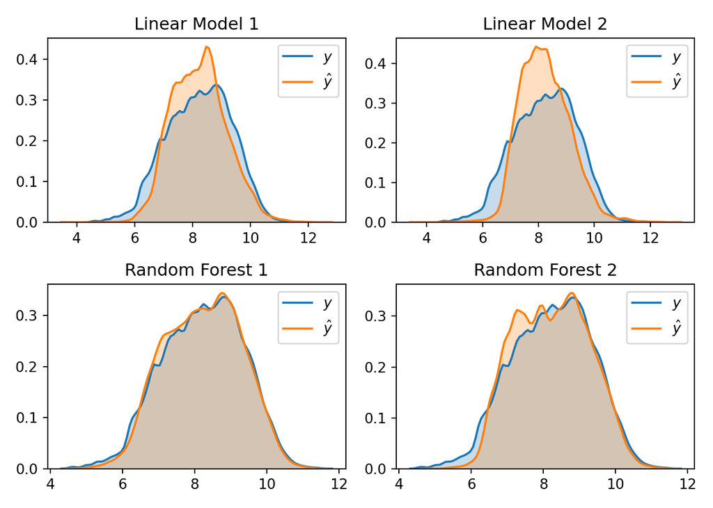

```python
annotate_axes(f, title=['Linear Model 1', 'Linear Model 2',
                        'Random Forest 1', 'Random Forest 2'], x_lab=True, y_lab=True)
f.tight_layout()
plt.show()
```

A reduction from 16 to 5 between the two models doesn’t appear to alter the outcome by much, and due to the principle of parsimony it is less likely to be overfit. There is clearly an issue with both linear models predicting values that are too centred around the most common log price values. This suggests that elements from the models which predict outliers are being lost. As the random forest models do not appear to suffer from this bias, this could mean that non-linear characteristics are being captured.

## Testing Predictions

This short section demonstrates the ability to predict a car price by using the minimal random forest model.

```python
import random

# testing the model
# choosing rf model 2
test_vars = pd.DataFrame({'powerPS': [50, 450],
                          'age': [16.0, 1.1],
                          'kilometer_125000': [0, 0],
                          'kilometer_150000': [1, 0],
                          'kilometer_<100000': [0, 1]})

def test_predictions(test_vars):
    grid.fit(df_dummies[m2_vars], df_dummies['log_price'])
    rf_best = grid.best_estimator_
    x_train, x_test, y_train, y_test = train_test_split(df_dummies[m2_vars],
                                                        df_dummies['log_price'],
                                                        test_size=0.8)
    rf_best.fit(x_train, y_train)
    rf_y_pred = [round(x, 2) for x in list(rf_best.predict(test_vars))]

    return rf_y_pred
```

```python
np.exp(test_predictions(test_vars))  # seems reasonable
```

```
array([ 1863.10550356, 52052.07818754])
```

These values seem reasonable, indicating that it is likely that this model would do a good job of predicting car values from just the power, age, and number of kilometers driven.

# Data Cleaning Appendix

```python
from datetime import date
import pandas as pd
from googletrans import Translator


def read_clean_data(file: str):
    """Read in and clean the Kaggle car data.

    Clean by removing outlier values from the various variables.
    These values were identified prior to this analysis. Also
    removes large number of columns that don't provide any useful
    information.
    Provides outputs, the clean file, and a boolean series giving integer
    postions of dropped columns

    Args:
        file (str): the file and path location to read in
    """
    # read in the data, special encoding required
    df = pd.read_csv(file, encoding="latin-1")
    # remove some questionable values, due to large number of rows
    # consider it fine to remove values that are possibly real but
    # will not improve models
    invalid_year = (df['yearOfRegistration'] > 2020) |\
                   (df['yearOfRegistration'] < 1950)
    invalid_price = (df['price'] > 100000) |\
                    (df['price'] < 100)
    invalid_power = (df['powerPS'] > 500) |\
                    (df['powerPS'] < 50)
    # variable used to remove outliers
    match = invalid_price | invalid_year | invalid_power
    match_dropped = {"Number of dropped rows:": match.sum(),
                     "Percentage of dropped rows:": (match.sum()/len(df))}
    # drop matched rows, also remove columns that are not required
    df = df[-match]\
        .drop([
            'dateCrawled',
            'seller',  # almost all one value
            'offerType',  # almost all one value
            'name',  # too many unique values
            'abtest',  # uninterpretable ebay code
            'lastSeen',
            'nrOfPictures',  # all zero
            'dateCreated',
            'model'  # far too many values
        ], axis=1)
    return df, match_dropped


df, match_dropped = read_clean_data("~/data/car_ml/autos.csv")
match_dropped  # count of rows removed in cleaning
# find number of rows with NA values
print("Total NA Values:", df.shape[0] - df.dropna().shape[0])
df = df.dropna()  # drop NA rows


def translate_rows_de(df: pd.DataFrame, cols: list):
    """Translate selected rows in a dataframe from de to en.

    Utilises googles translation API to accurately translate text
    contained within a dataframe. For efficient use first the number of
    unique values in each chosen column are found and translated. These
    may then be added back into the dataframe using pandas.replace.
    This avoids applying the translation API to each row, which does not
    work with a large dataframe.

    Args:
        df (pd.DataFrame): a dataframe with values that require translation
        cols (list): columns containing rows to translate
    """
    # initialise google Translator object
    translator = Translator()
    translations = {}  # empty dict to store translations
    # loop through each column specified above in the df
    # find unique categorical values for each
    # for each unique value per row translate from de to en
    # store the translation in the dictionary
    for column in cols:
        # unique elements of the column
        unique_elements = df[column].unique()
        for element in unique_elements:
            # add translation to the dictionary
            translations[element] = translator.translate(
                element, src='de', dest='en').text
    df = df.replace(translations)
    return df


# columns that require translation from german
cols = [
    'vehicleType',
    'notRepairedDamage',
    'fuelType',
    'gearbox'
]

# run translation function on predetermined rows
df = translate_rows_de(df, cols=cols)

# one translation needs correcting
df = df\
    .replace('manually', 'manual')
df = df.rename(columns={'notRepairedDamage': 'damaged'})  # rename for clarity


def find_age(df: pd.DataFrame, year_col: str, month_col: str):
    """Convert the dataframe to work with date manipulation.

    Both *_col inputs must evaluate to a column found within the
    dataframe, with a year and month in the correct format.

    Args:
        df (pd.DataFrame): [TODO:description]
        year_col (str): year in the format: 2020
        month_col (str): month in the format: 01
    """
    # create date type from month and year of registration
    date_reg = df.rename(
        columns={
            year_col: 'year',
            month_col: 'month'
        }
    )[['year', 'month']]
    date_reg['day'] = '1'  # required for to_datetime
    # change to date class, coerce removes invalid dates
    date_reg = pd.to_datetime(date_reg, errors='coerce')
    # subtract date from current date to find age

    # run function days_subtract on all rows
    date_reg = date_reg.apply(lambda x: pd.to_datetime(date.today()) - x)
    df['age'] = date_reg.dt.days/365  # age in years
    df = df.drop([year_col, month_col], axis=1)  # remove old cols
    return df


df = find_age(
    df,
    year_col='yearOfRegistration',
    month_col='monthOfRegistration'
)

# invalid dates are now classified as NA, remove them
# find number of rows with NA values
print("Number of NA Values:", df.shape[0] - df.dropna().shape[0])
df = df.dropna()  # drop NA rows


def join_postcodes(df: pd.DataFrame, pc: str):
    # read in detailed postcode data from GeoNames
    # keep only largest authority district
    # remove duplicate rows (since smaller authorities are gone)
    pc_df = pd.read_csv(pc, sep="\t", header=None)\
        .iloc[:, [1, 3]]\
        .drop_duplicates()
    # rename for join
    pc_df.columns = ['postalCode', 'area']
    # setup a join to include new area column with associated postcode
    df = df.set_index('postalCode')\
        .join(pc_df.set_index('postalCode'))\
        .reset_index()
    return df


# DE postcodes from GeoNames
df = join_postcodes(df, "~/data/car_ml/DE.txt")

# improved category, far fewer unique values
# number of unique postcodes
len(df['postalCode'].unique())
# number of unique areas
len(df['area'].unique())
df = df.drop('postalCode', axis=1)

df.to_csv("~/data/car_ml/derived/cars_cleaned.csv")
```

# Bibliography

Benoit, Kenneth. 2011. “Linear Regression Models with Logarithmic Transformations,” 8.

Calinski, T., and J. Harabasz. 1974. “A Dendrite Method for Cluster Analysis.” *Communications in Statistics - Theory and Methods* 3 (1): 1–27. https://doi.org/10.1080/03610927408827101.

Crawley, MJ. 2015. “Statistics. An Introduction Using R. 2nd Rd.”

Hawkins, Douglas M. 2004. “The Problem of Overfitting.” *Journal of Chemical Information and Computer Sciences* 44 (1): 1–12. https://doi.org/10.1021/ci0342472.

Liaw, Andy, and Matthew Wiener. 2002. “Classification and Regression by randomForest” 2: 6.

[^1]: The *Elbow Method* is commonly used to determine a suitable number of clusters. See https://www.scikit-yb.org/en/latest/api/cluster/elbow.html